# Fit Arrhenius Respiration Model

Hao-Ran Wu ( haoranwu @ zju.edu.cn )

2022-09-18

In this section we are concerned about how to fit Arrhenius respiration models through the function `respir.fit()`.

## Code Example(s)

```r
# Fit Arrhenius Respiration Models
# ********************************
#
# Fit Arrhenius models (Görres et al., 2016) from field measurements of soil
# temperature at 5cm, soil moisture at 10 cm, and soil respiration, at a larch
# forest in Mt. Fuji in 2015. Data provided by Dr. Naishen Liang (Email:
# liang@nies.go.jp)
#
# ********************************
# List of variables and units for this example
#
# 'path'        path of a CSV file, which contains four columns (with table titles)
#                * column 1(time):   a character representing observed time
#                * column 2(t_s):    soil temperature (Celsius)
#                * column 3(theta):  soil water content (%). Valid from 0-100
#                * column 4(Rs):     ecosystem respiration (µmol CO2 m−2 s−1)
#
# ********************************
# Step 1: import package
require(bproce)

# Step 2: choose parameters
path  <- "./data/3-1 Soil Respiration Measurements in Mt. Fuji.csv"

# Step 3: read data
dat   <- read.csv(path) # read the CSV file
                  #  * column 1 ($time): a character representing observed time
                  #  * column 2 ($t_s): temperature (Celsius)
                  #  * column 3 ($theta): soil water content (%). Valid from 0-100
                  #  * column 4 ($Rs): ecosystem respiration (µmol CO2 m−2 s−1)

# Step 4: fit the model
md <- respir.fit(dat$Rs, dat$t_s, method = "t4.arrhenius") # fit the model

cat(   # summarize the result
  paste("***** Model 1: Log-linear *****\n"),
  paste("R10 =", round(md$coef[["R10"]], 3), "\n"),
  paste("E0 =", round(md$coef[["E0"]], 3), "\n"),
  paste("Multiple R-squared:", round(md$r.squared, 3), "\n"),
  paste("Adjusted R-squared:", round(md$adj.r.squared, 3), "\n")
)

# Step 5: model prediction
R10 <- md$coef[["R10"]] # extract model parameter
E0 <- md$coef[["E0"]]   # extract model parameter
ta <- dat$t_s           # soil temperature at which respiration is to be predicted

eval(parse(text = gsub("T","ta",md$formula)))  # make predictions
                        # results are stored in the variable 'R'

smoothScatter(
  dat$t_s, dat$R,
  xlab = "Soil Temperature at 5cm",
  ylab = "Soil Respiration",
  main = "Fit Arrhenius Model"
)                       # soil respiration versus soil temperature
lines(dat$t_s, R)       # fitted Arrhenius model
```

## Explanation

**Step1:** Load the package `bproce` through the `require()` function.

```r
require(bproce)
```

**Step2:** Choose model parameters.

- `path`: the path of a CSV file which the data are to be read from. Each row of the file appears as one line, and columns are separated by commas (,). The first row appears as the table title. The sample file “3-1 Soil Respiration Measurements in Mt. Fuji.csv” contains four columns:
  - Column 1 (`$time`): A character representing observed time. The format is ‘dd/mm/yyyy hh:mm’, where ‘dd’ refers to day, ‘mm’ refers to month, and ‘yyyy’ refers to the year number. ‘hh’ refers to hour and ‘mm’ refers to minute. However, this column will not be used in this example.
  - Column 2 (`$t_s`): Soil temperature measured at 5cm (Celsius).
  - Column 3 (`$theta`): Soil water content (%). Valid from 0–100. However, this column will not be used in this example.
  - Column (`$Rs`): Measured soil respiration (µmol CO<sub>2</sub> m<sup>−2</sup> s<sup>−1</sup>).

```r
path  <- "./data/3-1 Soil Respiration Measurements in Mt. Fuji.csv"
```

**Step3:** Read data. Read the CSV file in table format and creates a data frame through the function `read.csv()`.

```r
dat   <- read.csv(path) # read the CSV file
                  #  * column 1 ($time): a character representing observed time
                  #  * column 2 ($t_s): temperature (Celsius)
                  #  * column 3 ($theta): soil water content (%). Valid from 0-100
                  #  * column 4 ($Rs): ecosystem respiration (µmol CO2 m−2 s−1)

head(dat)         #print first parts of the data
```

```
              time   t_s theta    Rs
1 18/03/2015 00:00 -1.35  23.4 0.568
2 18/03/2015 02:00 -1.41  23.2 0.500
3 18/03/2015 04:00 -1.50  23.0 0.298
4 18/03/2015 06:00 -1.36  22.8 0.237
5 18/03/2015 08:00 -1.15  22.7 0.269
6 18/03/2015 10:00 -1.38  22.5 0.551
```

**Step4:** Fit the model. In Arrhenius model, soil respiration ($R_s$, µmol CO<sub>2</sub> m<sup>−2</sup> s<sup>−1</sup>) is modeled as a function of the temperature ($T$, <sup>o</sup>C):

$$R=R_{10}·e^{E_0[\frac{1}{56.02}-\frac{1}{T+273.15-227.13}]},\quad(1)$$

$R_{10}$ is the respiration rate at a reference temperature of 10 <sup>o</sup>C (a.k.a. reference respiration), $E_0$ is the temperature sensitivity coefficient (<sup>o</sup>C).

```r
md <- respir.fit(dat$Rs, dat$t_s, method = "t4.arrhenius")
```

Now summarize the model fit:

```r
cat(   # summarize the result
  paste("***** Model 1: Log-linear *****\n"),
  paste("R10 =", round(md$coef[["R10"]], 3), "\n"),
  paste("E0 =", round(md$coef[["E0"]], 3), "\n"),
  paste("Multiple R-squared:", round(md$r.squared, 3), "\n"),
  paste("Adjusted R-squared:", round(md$adj.r.squared, 3), "\n")
)
```

```
***** Model 1: Log-linear *****
 R10 = 2.021
 E0 = 359.84
 Multiple R-squared: 0.845
 Adjusted R-squared: 0.845
```

where `R10` corresponds to $R_{10}$, `E0` corresponds to $E_0$ in equation (1).

**Step5:** Model prediction. Predict $R_s$ using the fitted model:

```r
R10 <- md$coef[["R10"]] # extract model parameter
E0 <- md$coef[["E0"]]   # extract model parameter
ta <- dat$t_s           # soil temperature at which respiration is to be predicted

eval(parse(text = gsub("T","ta",md$formula)))  # make predictions
                        # results are stored in the variable 'R'

print(head(data.frame(
  t_s = dat$t_s, observed_Rs = dat$Rs, predicted_Rs = R
)), digits = 3)
```

```
    t_s observed_Rs predicted_Rs
1 -1.35       0.568        0.395
2 -1.41       0.500        0.391
3 -1.50       0.298        0.384
4 -1.36       0.237        0.394
5 -1.15       0.269        0.409
6 -1.38       0.551        0.393
```

Create a plot of $R_s$ against $t_s$ to compare observed and predicted values:

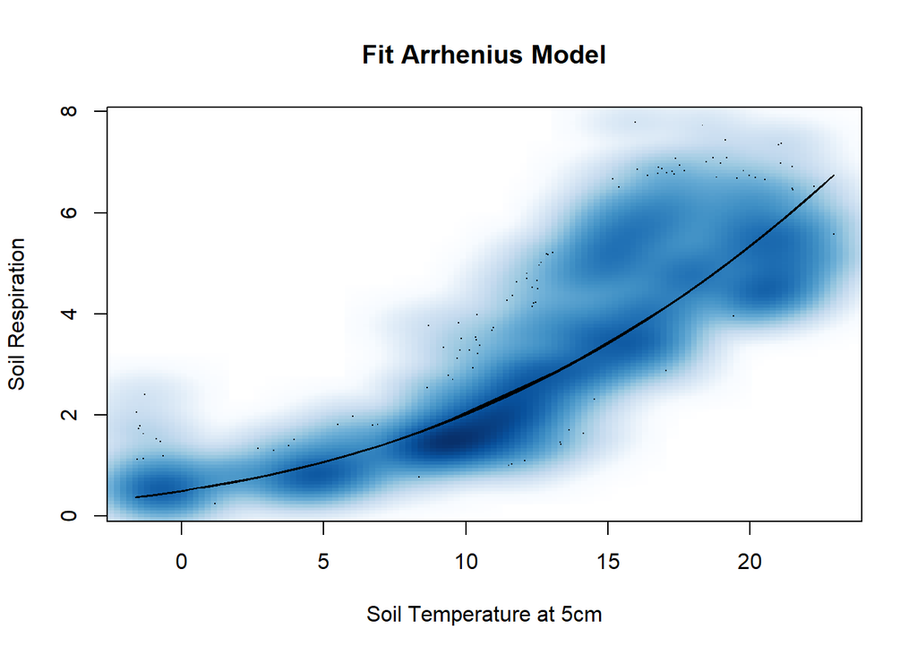

```r
smoothScatter(
  dat$t_s, dat$R,
  xlab = "Soil Temperature at 5cm",
  ylab = "Soil Respiration",
  main = "Fit Arrhenius Model"
)                       # soil respiration versus soil temperature
lines(dat$t_s, R)       # fitted Arrhenius model
```

## Reference

Görres, C. M., Kammann, C., and Ceulemans, R. (2016). Automation of soil flux chamber measurements: Potentials and pitfalls. Biogeosciences, 13(6), 1949–1966.